# 非線形最小二乗法のまとめ

UPDATE: 2023-04-30 15:37:59

## 非線形最小二乗法のまとめ

ここでは非線形最小二乗法を用いて、非線形な関数のフィッティングについての実装をまとめる。使用しているパッケージは`nls`パッケージではなく、`gslnls`パッケージ。便利な計算アルゴリズムや漸近信頼区間と予測区間の計算ができる便利なパッケージ。

- [GSL nonlinear least squares fitting in R](https://www.jchau.org/2021/10/12/gsl-nonlinear-least-squares-fitting-in-r/#ref-R83)
- [Asymptotic confidence intervals for NLS regression in R](https://www.jchau.org/2021/07/12/asymptotic-confidence-intervals-for-nls-regression-in-r/)
- JorisChau/gslnls
- [A collection of self-starters for nonlinear regression in R](https://www.statforbiology.com/2020/stat_nls_usefulfunctions/)
- [Nonlinear regression](https://rpubs.com/abbyhudak/nonlinreg)

このノートは、非線形最小二乗法の理論やデータに対する関数についての説明もない。ただただ実装をまとめているだけ。必要なライブラリを読み込んでおく。

```r
library(NISTnls)
library(gslnls)
library(tidyverse)
library(aomisc)
```

## 非線形関数

### Michaelis-Menten equation

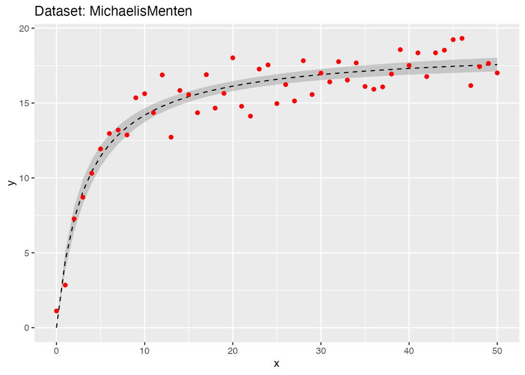

```r
set.seed(1989)
x <- seq(0, 50, 1)
y <- ((runif(1, 10, 20)*x)/(runif(1, 0, 10) + x)) + rnorm(n = length(x), 0, 1)
MichaelisMenten <- data.frame(y, x)

MichaelisMenten_nsl <- gsl_nls(
  fn = y ~ (b1 * x / (b2 + x)),
  data = MichaelisMenten,
  start = c(b1 = 1, b2 = 1),
  control = gsl_nls_control(maxiter = 50),
  algorithm = 'lm'
)

# as.matrix(coef(MichaelisMenten_nsl))
cbind(
  MichaelisMenten,
  predict(MichaelisMenten_nsl, interval = "confidence", level = 0.95)
) %>%
  ggplot(., aes(x, y))+
  geom_ribbon(aes(ymin = lwr, ymax = upr), alpha = 0.2) +
  geom_line(aes(x, fit), linetype = 'dashed') +
  geom_point(col = 'red') +
  ggtitle('Dataset: MichaelisMenten')
```

### Polynomial

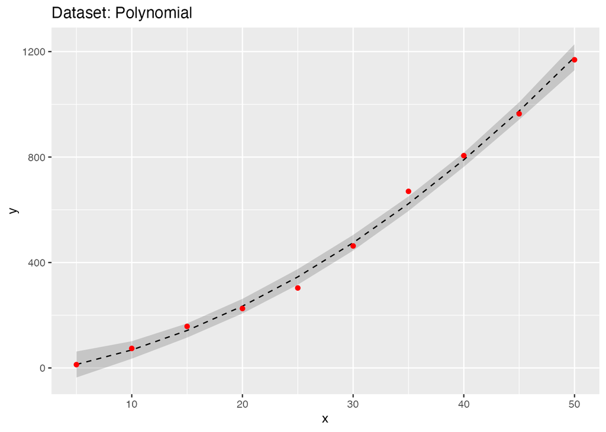

```r
Polynomial <- data.frame(
  x = seq(5, 50, 5),
  y = c(12.6, 74.1, 157.6, 225.5, 303.4, 462.8, 669.9, 805.3, 964.2, 1169)
)

Polynomial_nsl <- gsl_nls(
  fn = y ~ a + b*x + c*x^2,
  data = Polynomial,
  start = c(a = 1, b = 1, c = 1),
  control = gsl_nls_control(maxiter = 50),
  algorithm = 'lm'
)

# as.matrix(coef(Polynomial_nsl))
cbind(
  Polynomial,
  predict(Polynomial_nsl, interval = "confidence", level = 0.95)
) %>%
  ggplot(., aes(x, y))+
  geom_ribbon(aes(ymin = lwr, ymax = upr), alpha = 0.2) +
  geom_line(aes(x, fit),linetype = 'dashed') +
  geom_point(col = 'red') +
  ggtitle('Dataset: Polynomial')
```

### ExponentialDecay

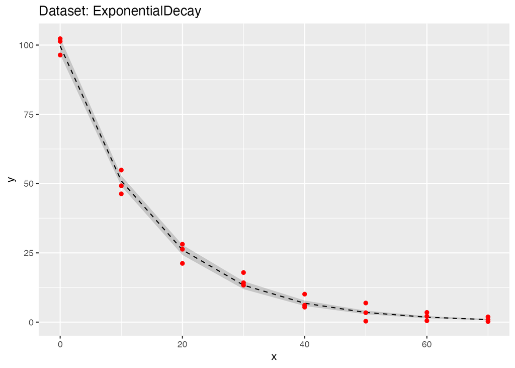

```r
ExponentialDecay <- structure(list(
  x = c(0L, 10L, 20L, 30L, 40L, 50L, 60L, 70L, 0L, 10L, 20L, 30L, 40L, 50L, 60L, 70L, 0L, 10L, 20L, 30L, 40L, 50L, 60L, 70L),
  y = c(96.4, 46.3, 21.2, 17.89, 10.1, 6.9, 3.5, 1.9, 102.3, 49.2, 26.31, 14.22, 5.4, 3.4, 0.5, 0.2, 101.33, 54.89, 28.12, 13.33, 6.11, 0.35, 2.1, 0.922)),
  class = "data.frame", row.names = c(NA, -24L)
  )

ExponentialDecay_nsl <- gsl_nls(
  fn = y ~ a*exp(k*x),
  data = ExponentialDecay,
  start = c(a = 100, k = 0.01),
  control = gsl_nls_control(maxiter = 100),
  algorithm = 'lm'
)

# as.matrix(coef(ExponentialDecay_nsl))
cbind(
  ExponentialDecay,
  predict(ExponentialDecay_nsl, interval = "confidence", level = 0.95)
) %>%
  ggplot(., aes(x, y))+
  geom_ribbon(aes(ymin = lwr, ymax = upr), alpha = 0.2) +
  geom_line(aes(x, fit),linetype = 'dashed') +
  geom_point(col = 'red') +
  ggtitle('Dataset: ExponentialDecay')
```

### Asymptotic

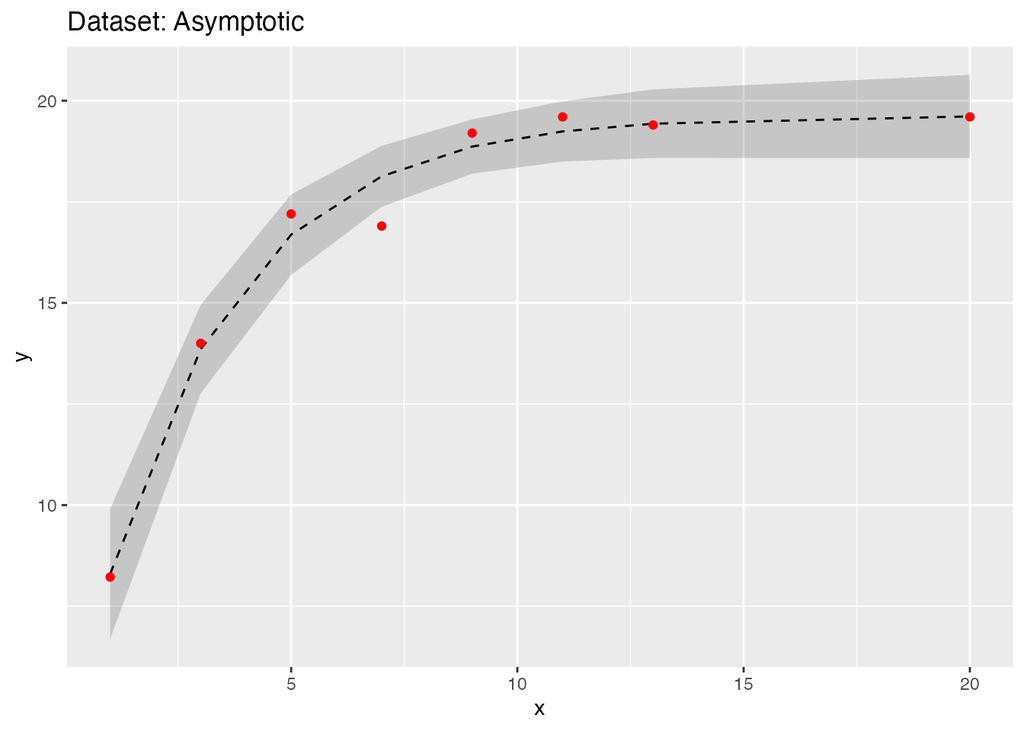

```r
Asymptotic <- data.frame(
  x = c(1, 3, 5, 7, 9, 11, 13, 20),
  y = c(8.22, 14.0, 17.2, 16.9, 19.2, 19.6, 19.4, 19.6)
)


Asymptotic_nsl <- gsl_nls(
  fn = y ~ a-(a-b)*exp(-c*x),
  data = Asymptotic,
  start = c(a = 1, b = 1, c = 0.01),
  control = gsl_nls_control(maxiter = 1000),
  algorithm = 'lm'
)

# as.matrix(coef(Asymptotic_nsl))
cbind(
  Asymptotic,
  predict(Asymptotic_nsl, interval = "confidence", level = 0.95)
) %>%
  ggplot(., aes(x, y))+
  geom_ribbon(aes(ymin = lwr, ymax = upr), alpha = 0.2) +
  geom_line(aes(x, fit),linetype = 'dashed') +
  geom_point(col = 'red') +
  ggtitle('Dataset: Asymptotic')
```

### Power

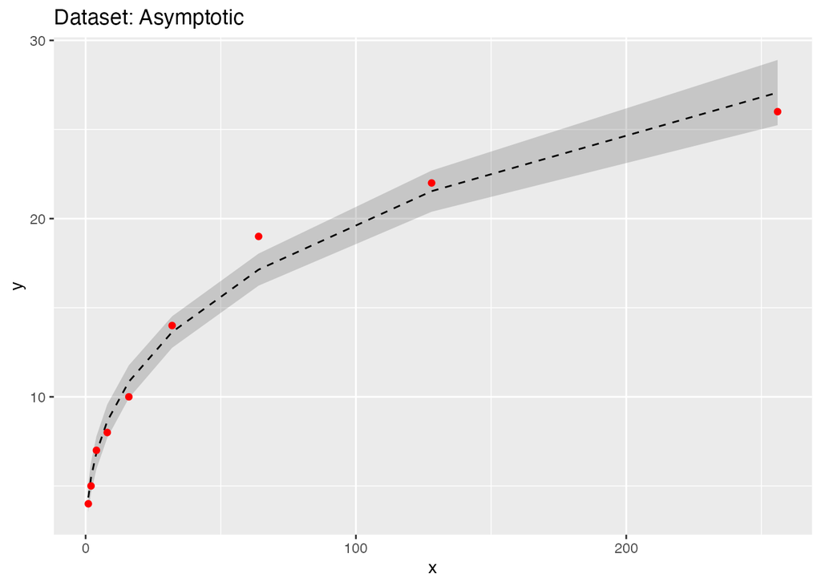

```r
Power <- structure(list(
  x = c(1L, 2L, 4L, 8L, 16L, 32L, 64L, 128L, 256L),
  y = c(4, 5, 7, 8, 10, 14, 19, 22, 26)),
  row.names = c(NA, -9L), class = "data.frame")


Power_nsl <- gsl_nls(
  fn = y ~ a*x^b,
  data = Power,
  start = c(a = 0.1, b = 0.01),
  control = gsl_nls_control(maxiter = 1000),
  algorithm = 'lm'
)

# as.matrix(coef(Power_nsl))
cbind(
  Power,
  predict(Power_nsl, interval = "confidence", level = 0.95)
) %>%
  ggplot(., aes(x, y))+
  geom_ribbon(aes(ymin = lwr, ymax = upr), alpha = 0.2) +
  geom_line(aes(x, fit),linetype = 'dashed') +
  geom_point(col = 'red') +
  ggtitle('Dataset: Asymptotic')
```

### Logarithmic

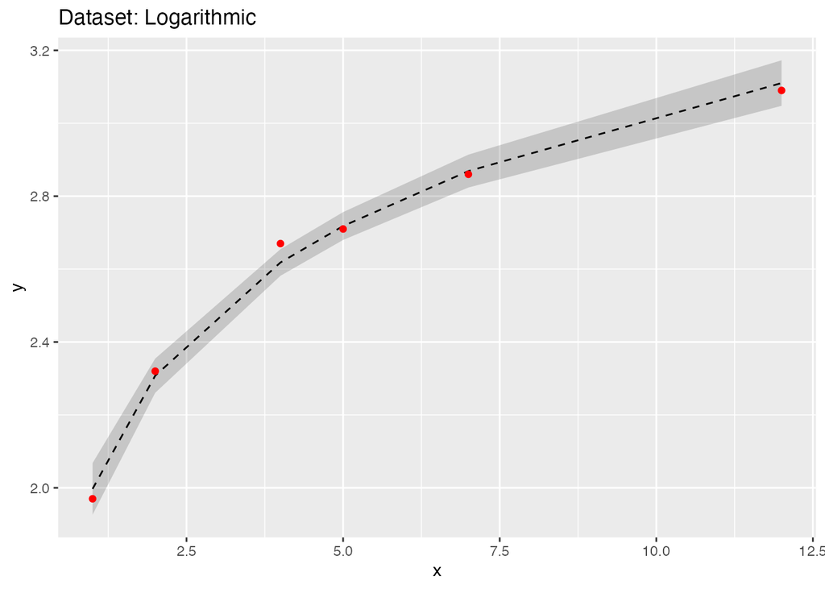

```r
Logarithmic <- data.frame(
  x = c(1,2,4,5,7,12),
  y = c(1.97, 2.32, 2.67, 2.71, 2.86, 3.09)
  )


Logarithmic_nsl <- gsl_nls(
  fn = y ~ a + b * log(x),
  data = Logarithmic,
  start = c(a = 0.1, b = 0.1),
  control = gsl_nls_control(maxiter = 1000),
  algorithm = 'lm'
)

# as.matrix(coef(Logarithmic_nsl))
cbind(
  Logarithmic,
  predict(Logarithmic_nsl, interval = "confidence", level = 0.95)
) %>%
  ggplot(., aes(x, y))+
  geom_ribbon(aes(ymin = lwr, ymax = upr), alpha = 0.2) +
  geom_line(aes(x, fit),linetype = 'dashed') +
  geom_point(col = 'red') +
  ggtitle('Dataset: Logarithmic')
```

### Rectangular

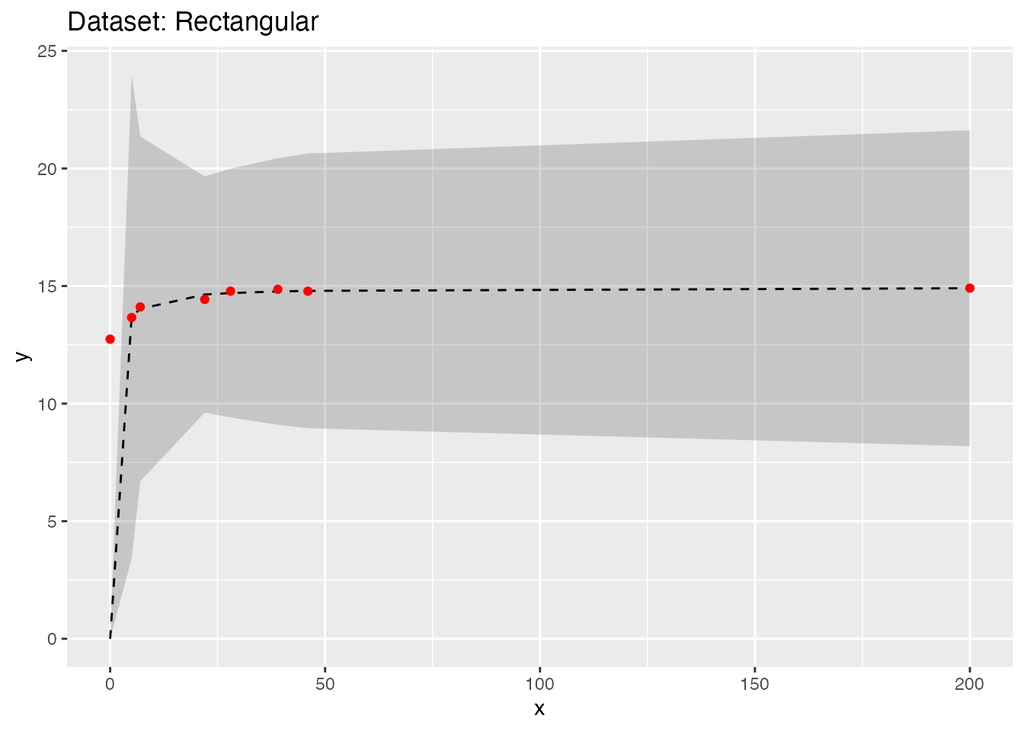

```r
Rectangular <- data.frame(
  x = c(0, 5, 7, 22, 28, 39, 46, 200),
  y = c(12.74, 13.66, 14.11, 14.43, 14.78, 14.86, 14.78, 14.91)
)


Rectangular_nsl <- gsl_nls(
  fn = y ~ a*x/(b+x),
  data = Rectangular,
  start = c(a = 10, b = 0.5),
  control = gsl_nls_control(maxiter = 1000),
  algorithm = 'lm'
)

# as.matrix(coef(Rectangular_nsl))
cbind(
  Rectangular,
  predict(Rectangular_nsl, interval = "confidence", level = 0.95)
) %>%
  ggplot(., aes(x, y))+
  geom_ribbon(aes(ymin = lwr, ymax = upr), alpha = 0.2) +
  geom_line(aes(x, fit),linetype = 'dashed') +
  geom_point(col = 'red') +
  ggtitle('Dataset: Rectangular')
```

### Weibull

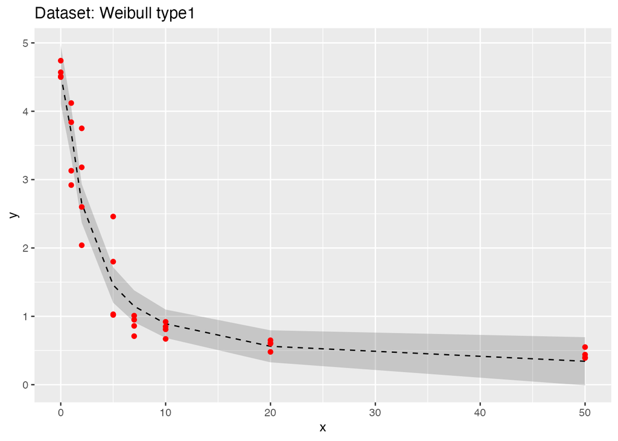

```r
Weibull <- structure(list(
  x = c(0L, 0L, 0L, 0L, 1L, 1L, 1L, 1L, 2L, 2L,2L, 2L, 5L, 5L, 5L, 5L, 7L, 7L, 7L, 7L, 10L, 10L, 10L, 10L, 20L, 20L, 20L, 20L, 50L, 50L, 50L, 50L),
  y = c(4.74, 4.57, 4.51, 4.5, 4.12, 3.84, 3.13, 2.92, 3.75, 3.18, 2.6, 2.04, 2.46, 1.8, 1.03, 1.02, 1.01, 0.95, 0.86, 0.71, 0.92, 0.85, 0.81, 0.67, 0.65,0.61, 0.6, 0.48, 0.55, 0.44, 0.4, 0.39)),
  class = "data.frame", row.names = c(NA, -32L))

Weibull1_nsl <- gsl_nls(
  fn = y ~ c + (d-c)*exp(-exp(-b*(log(x)-log(e)))),
  data = Weibull,
  start = c(b = 1, c = 0.5, d = 5, e = 3),
  control = gsl_nls_control(maxiter = 1000),
  algorithm = 'lm'
)

# as.matrix(coef(Weibull1_nsl))
cbind(
  Weibull,
  predict(Weibull1_nsl, interval = "confidence", level = 0.95)
) %>%
  ggplot(., aes(x, y))+
  geom_ribbon(aes(ymin = lwr, ymax = upr), alpha = 0.2) +
  geom_line(aes(x, fit),linetype = 'dashed') +
  geom_point(col = 'red') +
  ggtitle('Dataset: Weibull type1')
```

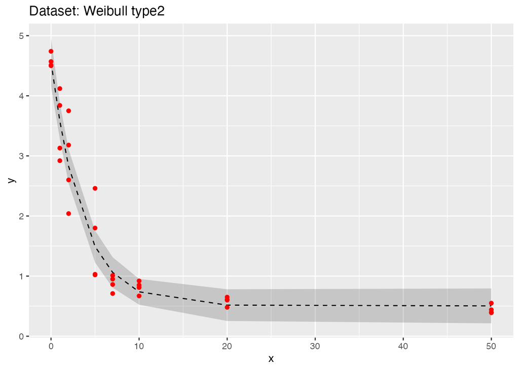

```r
Weibull2_nsl <- gsl_nls(
  fn = y ~ c + (d-c)*(1-exp(-exp(b*(log(x)-log(e))))),
  data = Weibull,
  start = c(b = 1, c = 0.5, d = 5, e = 3),
  control = gsl_nls_control(maxiter = 1000),
  algorithm = 'lm'
)

# as.matrix(coef(Weibull2_nsl))
cbind(
  Weibull,
  predict(Weibull2_nsl, interval = "confidence", level = 0.95)
) %>%
  ggplot(., aes(x, y))+
  geom_ribbon(aes(ymin = lwr, ymax = upr), alpha = 0.2) +
  geom_line(aes(x, fit),linetype = 'dashed') +
  geom_point(col = 'red') +
  ggtitle('Dataset: Weibull type2')
```

### Bragg

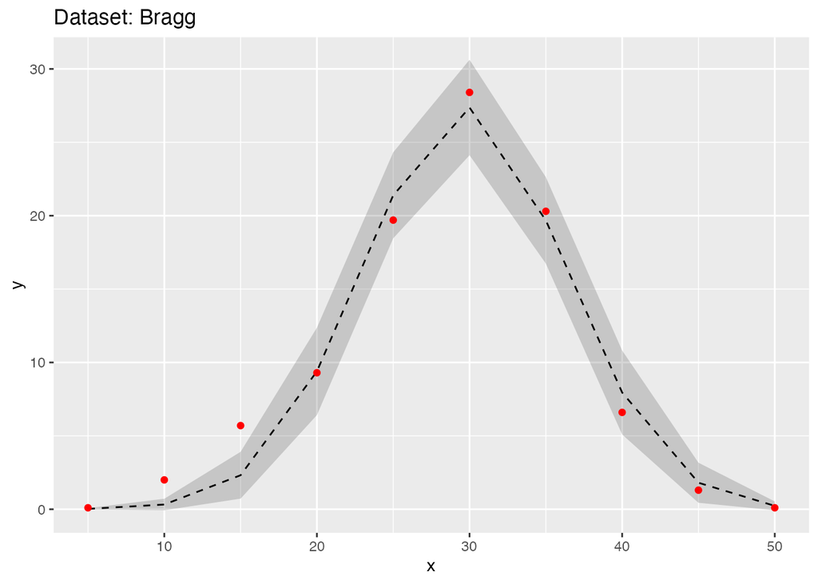

```r
Bragg <- data.frame(
  x = c(5, 10, 15, 20, 25, 30, 35, 40, 45, 50),
  y = c(0.1, 2, 5.7, 9.3, 19.7, 28.4, 20.3, 6.6, 1.3, 0.1)
)

Bragg_nsl <- gsl_nls(
  fn = y ~ d * exp(-b*(x-e)^2),
  data = Bragg,
  start = c(b = 0.1, d = 30, e = 30),
  control = gsl_nls_control(maxiter = 1000),
  algorithm = 'lm'
)

# as.matrix(coef(Bragg_nsl))
cbind(
  Bragg,
  predict(Bragg_nsl, interval = "confidence", level = 0.95)
) %>%
  ggplot(., aes(x, y))+
  geom_ribbon(aes(ymin = lwr, ymax = upr), alpha = 0.2) +
  geom_line(aes(x, fit),linetype = 'dashed') +
  geom_point(col = 'red') +
  ggtitle('Dataset: Bragg')
```

### Lorentz

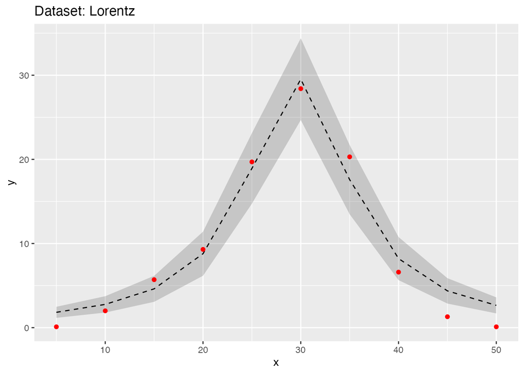

```r
Lorentz <- Bragg

Lorentz_nsl <- gsl_nls(
  fn = y ~ d / (1 + b*(x-e)^2),
  data = Lorentz,
  start = c(b = 0.1, d = 30, e = 30),
  control = gsl_nls_control(maxiter = 1000),
  algorithm = 'lm'
)

# as.matrix(coef(Lorentz_nsl))
cbind(
  Lorentz,
  predict(Lorentz_nsl, interval = "confidence", level = 0.95)
) %>%
  ggplot(., aes(x, y))+
  geom_ribbon(aes(ymin = lwr, ymax = upr), alpha = 0.2) +
  geom_line(aes(x, fit),linetype = 'dashed') +
  geom_point(col = 'red') +
  ggtitle('Dataset: Lorentz')
```

### Beta

Betaのデータは`gsl_nls()`関数では収束させることができなかったため、`aomisc`パッケージの関数を利用している。このパッケージの関数は特定の関数系に対して、初期値を自動的に計算できるため、非線形回帰分析を線形回帰分析と同じくらいスムーズに実行できる。

下記に使用方法がまとまっており、ここでもその利用方法に従っている。

- [A collection of self-starters for nonlinear regression in R](https://www.statforbiology.com/2020/stat_nls_usefulfunctions/)

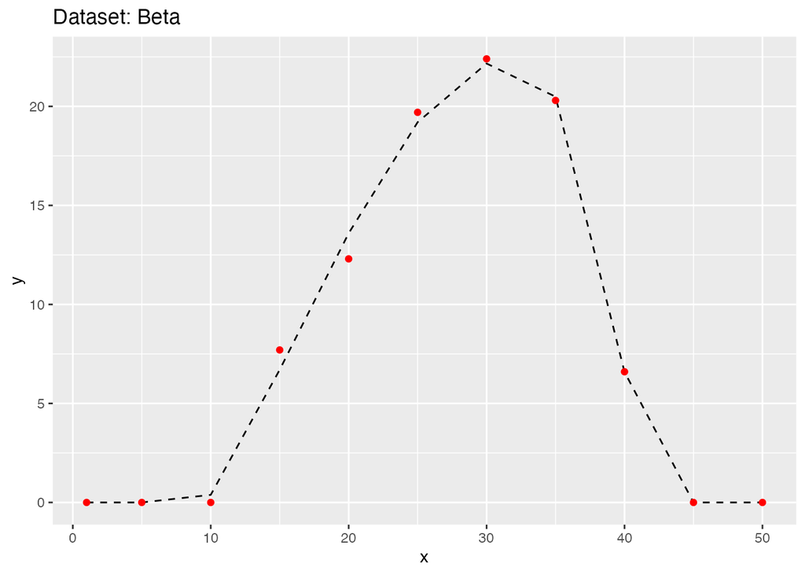

```r
Beta <- data.frame(
  x = c(1, 5, 10, 15, 20, 25, 30, 35, 40, 45, 50),
  y = c(0, 0, 0, 7.7, 12.3, 19.7, 22.4, 20.3, 6.6, 0, 0)
)
#
# Beta_nsl <- gsl_nls(
#   fn = y ~ d * (((x-xb)/(xo-xb))*((xc-x)/(xc-xo))^((xc-xo)/(xo-xb)))^b,
#   data = Beta,
#   start = c(b = 1.291, d = 22.294, xb = 9.438, xc = 40.464, xo = 31.154),
#   control = gsl_nls_control(maxiter = 1000),
#   algorithm = 'lm'
# )

model <- nls(y ~ NLS.beta(x, b, d, Xb, Xo, Xc), data = Beta)
# summary(model)

cbind(
  Beta,
  fit = predict(model, interval = "confidence", level = 0.95)
) %>%
  ggplot(., aes(x, y))+
  geom_line(aes(x, fit),linetype = 'dashed') +
  geom_point(col = 'red') +
  ggtitle('Dataset: Beta')
```

## NIST StRD Nonlinear Regression

下記は[NIST StRD Nonlinear Regression](https://www.itl.nist.gov/div898/strd/nls/nls_main.shtml)でアーカイブされているデータを扱っている。レベルはHigherのみ。

### Ratkowsky2

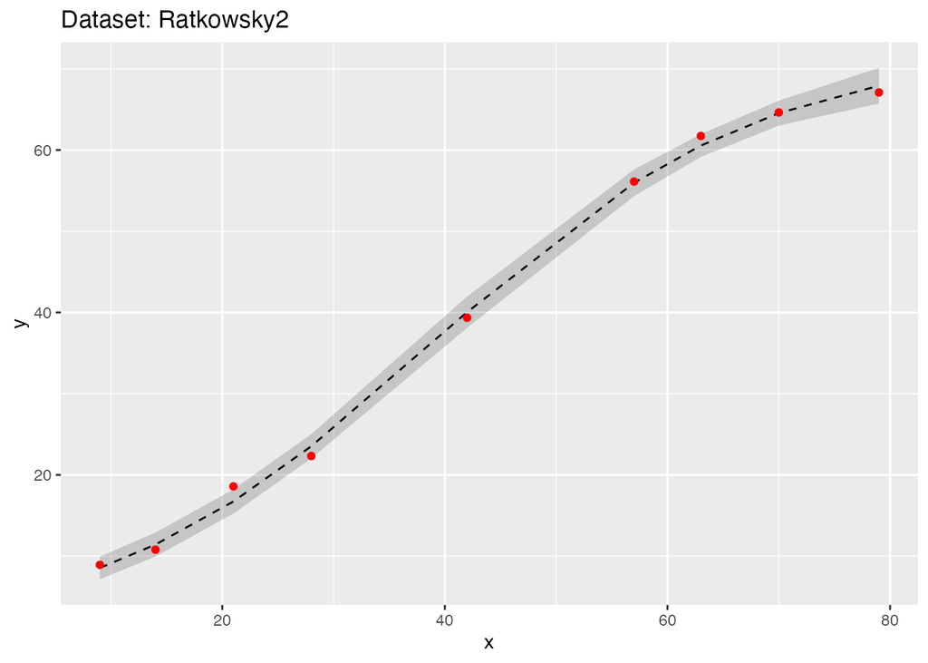

```r
Ratkowsky2_nsl <- gsl_nls(
  fn = y ~ b1 / (1 + exp(b2 - b3 * x)),
  data = Ratkowsky2,
  start = c(b1 = 100, b2 = 1, b3 = 0.1),
  control = gsl_nls_control(maxiter = 100)
)

#as.matrix(coef(Ratkowsky2_nsl))
cbind(
  Ratkowsky2,
  predict(Ratkowsky2_nsl, interval = "confidence", level = 0.95)
) %>%
  ggplot(., aes(x, y))+
  geom_ribbon(aes(ymin = lwr, ymax = upr), alpha = 0.2) +
  geom_line(aes(x, fit),linetype = 'dashed') +
  geom_point(col = 'red') +
  ggtitle('Dataset: Ratkowsky2')
```

### MGH09

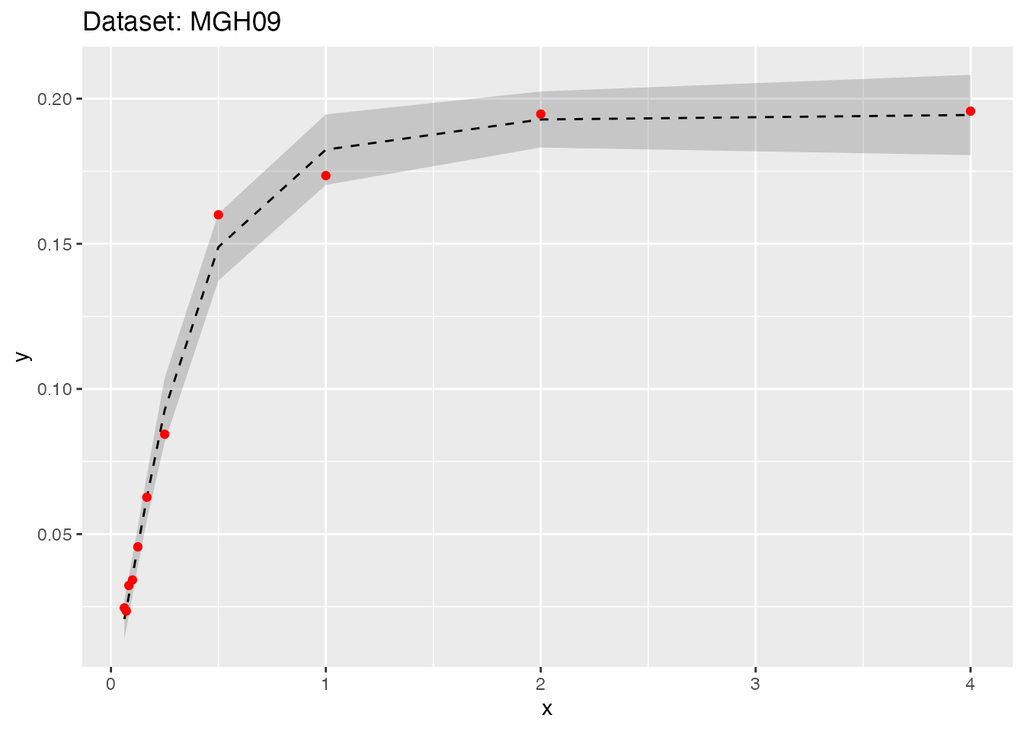

```r
MGH09_nsl <- gsl_nls(
  fn = y ~ (b1*(x^2 + b2*x)) / (x^2 + b3*x + b4),
  data = MGH09,
  start = c(b1 = 25, b2 = 39, b3 = 41.5, b4 = 39),
  control = gsl_nls_control(maxiter = 100)
)

# as.matrix(coef(MGH09_nsl))
cbind(
  MGH09,
  predict(MGH09_nsl, interval = "confidence", level = 0.95)
  ) %>%
  ggplot(., aes(x, y))+
  geom_ribbon(aes(ymin = lwr, ymax = upr), alpha = 0.2) +
  geom_line(aes(x, fit),linetype = 'dashed') +
  geom_point(col = 'red') +
  ggtitle('Dataset: MGH09')
```

### Thurber

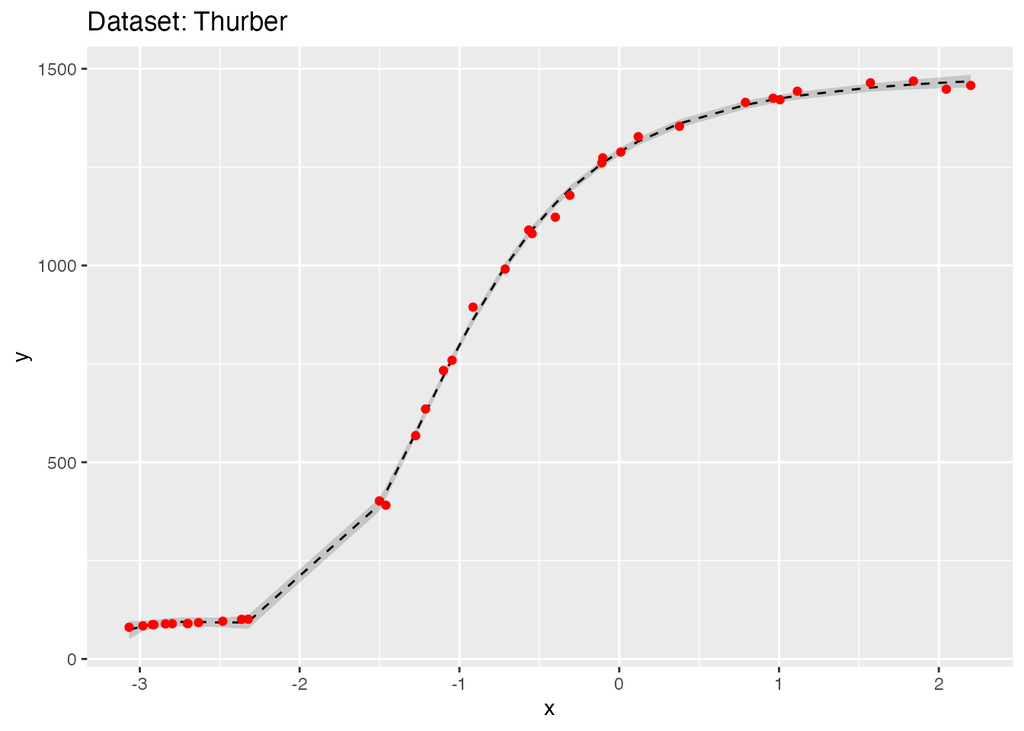

```r
Thurber_nsl <- gsl_nls(
  fn = y ~ (b1 + b2*x + b3*x^2 + b4*x^3)/(1 + b5*x + b6*x^2 + b7*x^3),
  data = Thurber,
  start = c(b1 = 1000, b2 = 1000, b3 = 400, b4 = 40, b5 = 0.7, b6 = 0.3, b7 = 0.03),
  control = gsl_nls_control(maxiter = 100)
)
# as.matrix(coef(Thurber_nsl))

cbind(
  Thurber,
  predict(Thurber_nsl, interval = "confidence", level = 0.95)
) %>%
  ggplot(., aes(x, y))+
  geom_ribbon(aes(ymin = lwr, ymax = upr), alpha = 0.2) +
  geom_line(aes(x, fit),linetype = 'dashed') +
  geom_point(col = 'red') +
  ggtitle('Dataset: Thurber')
```

### MGH10

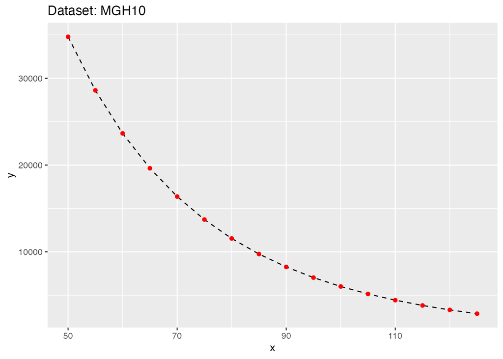

```r
MGH10_nsl <- gsl_nls(
  fn = y ~ b1 * exp(b2 / (x + b3)),
  data = MGH10,
  start = c(b1 = 2, b2 = 400000, b3 = 25000),
  control = gsl_nls_control(maxiter = 100000)
)

# as.matrix(coef(MGH10_nsl))
cbind(
  MGH10,
  predict(MGH10_nsl, interval = "confidence", level = 0.95)
) %>%
  ggplot(., aes(x, y))+
  geom_ribbon(aes(ymin = lwr, ymax = upr), alpha = 0.2) +
  geom_line(aes(x, fit),linetype = 'dashed') +
  geom_point(col = 'red') +
  ggtitle('Dataset: MGH10')
```

### Eckerle4

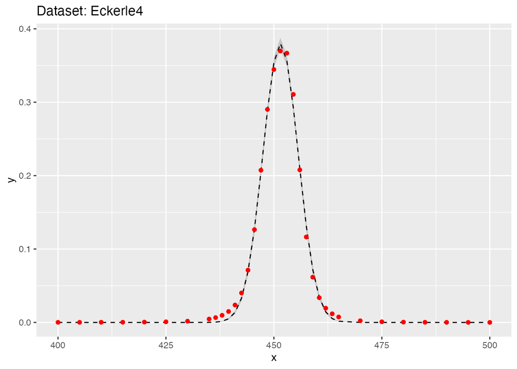

```r
Eckerle4_nsl <- gsl_nls(
  fn = y ~ (b1/b2) * exp((-1/2)*((x-b3)/b2)^2),
  data = Eckerle4,
  start = c(b1 = 1, b2 = 10, b3 = 500),
  control = gsl_nls_control(maxiter = 100)
)

# as.matrix(coef(Eckerle4_nsl))
cbind(
  Eckerle4,
  predict(Eckerle4_nsl, interval = "confidence", level = 0.95)
) %>%
  ggplot(., aes(x, y))+
  geom_ribbon(aes(ymin = lwr, ymax = upr), alpha = 0.2) +
  geom_line(aes(x, fit),linetype = 'dashed') +
  geom_point(col = 'red') +
  ggtitle('Dataset: Eckerle4')
```

### Ratkowsky3

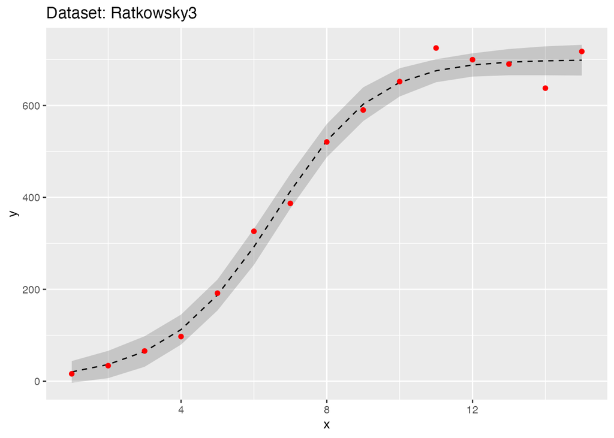

```r
Ratkowsky3_nsl <- gsl_nls(
  fn = y ~ b1 / (1 + exp(b2-b3*x))^(1/b4),
  data = Ratkowsky3,
  start = c(b1 = 100, b2 = 10, b3 = 1, b4 = 1),
  control = gsl_nls_control(maxiter = 100)
)

# as.matrix(coef(Ratkowsky3_nsl))
cbind(
  Ratkowsky3,
  predict(Ratkowsky3_nsl, interval = "confidence", level = 0.95)
) %>%
  ggplot(., aes(x, y))+
  geom_ribbon(aes(ymin = lwr, ymax = upr), alpha = 0.2) +
  geom_line(aes(x, fit),linetype = 'dashed') +
  geom_point(col = 'red') +
  ggtitle('Dataset: Ratkowsky3')
```

### Bennett5

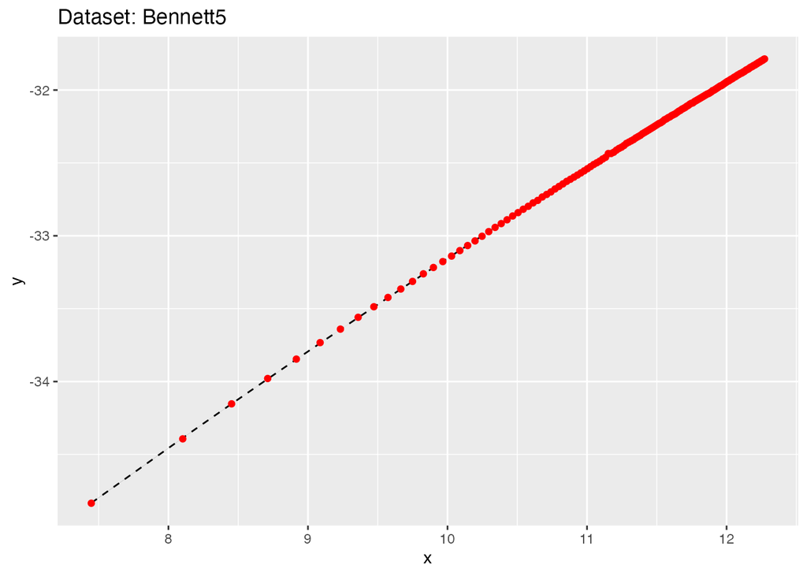

```r
Bennett5_nsl <- gsl_nls(
  fn = y ~ b1 * (b2 + x)^(-1/b3),
  data = Bennett5,
  start = c(b1 = -2000, b2 = 50, b3 = 0.8),
  control = gsl_nls_control(maxiter = 100)
)

# as.matrix(coef(Bennett5_nsl))
cbind(
  Bennett5,
  predict(Bennett5_nsl, interval = "confidence", level = 0.95)
) %>%
  ggplot(., aes(x, y))+
  geom_ribbon(aes(ymin = lwr, ymax = upr), alpha = 0.2) +
  geom_line(aes(x, fit),linetype = 'dashed') +
  geom_point(col = 'red') +
  ggtitle('Dataset: Bennett5')
```

### BoxBOD

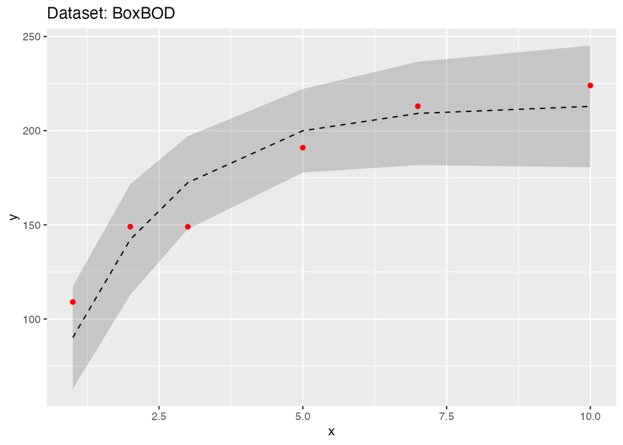

```r
BoxBOD <- tribble(
  ~y,~x,
109, 1,
149, 2,
149, 3,
191, 5,
213, 7,
224, 10
)

BoxBOD_nsl <- gsl_nls(
  fn = y ~ b1 * (1 - exp(-1*b2 * x)),
  data = BoxBOD,
  start = c(b1 = 1, b2 = 1),
  control = gsl_nls_control(maxiter = 100),
  algorithm = 'lmaccel', # デフォルトのlm(levenberg-Marquardt)では収束しない
)

# as.matrix(coef(BoxBOD_nsl))
cbind(
  BoxBOD,
  predict(BoxBOD_nsl, interval = "confidence", level = 0.95)
) %>%
  ggplot(., aes(x, y))+
  geom_ribbon(aes(ymin = lwr, ymax = upr), alpha = 0.2) +
  geom_line(aes(x, fit),linetype = 'dashed') +
  geom_point(col = 'red') +
  ggtitle('Dataset: BoxBOD')
```